# as_task4_kirsten_white

Kirsten White

10/23/2021

# **Introduction**

In this code, size distribution data on purple sea urchins collected from Naples Reef kelp removal site in 2010 is wrangled and visualized.

**Data Citation**: Reed, D. 2020. SBC LTER: Reef: Long-term experiment: Kelp removal: Urchin size frequency distribution ver 20. Environmental Data Initiative. https://doi.org/10.6073/pasta/5a1e9ef03aa47bd2225c0bb98a02a63b

```r
knitr::opts_chunk$set(echo = TRUE, warning = FALSE, message = FALSE)

library(tidyverse)
library(here)
library(janitor)
library(lubridate)
library(kableExtra)
```

### Read in the Data

```r
urchins_data <- read_csv(here("data", "urchins.csv")) %>%
  clean_names()
```

# **Section 1 - Purple Urchin Mean Size in Naples Reef 2010**

### Data Wrangling

Data is filtered to include observations for only Purple Urchins collected at the Naples Reef site in 2010

```r
purple_urchins_size_napl_10 <- urchins_data %>%
  mutate(date = mdy(date)) %>%
  mutate(year = year(date)) %>%
  filter(common_name == "Purple Urchin", site == "NAPL", year == 2010)

# ------ mdy not converting date to "date" class -----
```

### Data Visualization

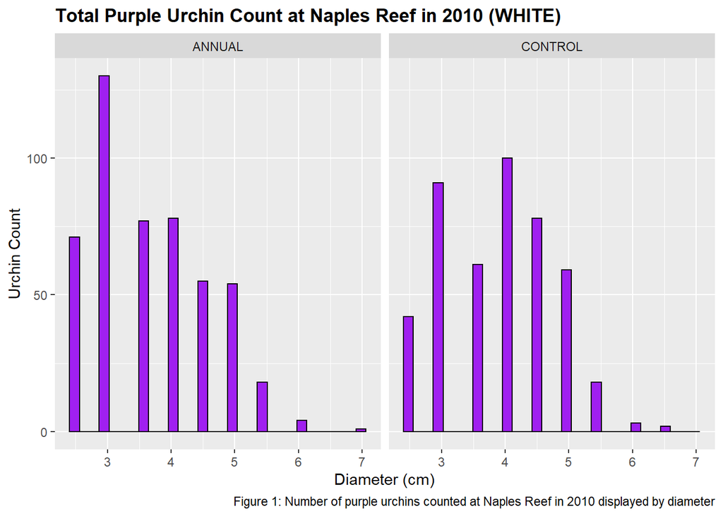

```r
ggplot(data = purple_urchins_size_napl_10, aes(x = size))+
  geom_histogram(color = "black", fill = "purple")+
  facet_wrap(~ treatment) +
  labs(x = "Diameter (cm)",
       y = "Urchin Count",
       title = "Total Purple Urchin Count at Naples Reef in 2010 (WHITE)",
       caption = "Figure 1: Number of purple urchins counted at Naples Reef in 2010 displayed by diameter") +
  theme(plot.title = element_text(face = "bold"))
```

Figure 1 indicates a lower central tendency in diameter of the purple urchins measured in the annual treatment group - skewing closer to 3 cm. Control group purple urchins appear more evenly distributed around a diameter of 4 cm.

### Summary Table

```r
purple_urchins_size_napl_10_summary <- purple_urchins_size_napl_10 %>%
  group_by(treatment) %>%
  summarize(mean_size = mean(size),
            median_size = median(size),
            sd_size = sd(size),
            sample_size = n()) %>%
  kbl(caption = "Table 1: Summary statistics of Purple Urchins collected from Naples Reef, 2010",
      col.names = c("Treatment Type", "Mean (cm)", "Median (cm)", "Standard Deviation", "Sample Size (n)"),
      digits = 1) %>%
  kable_minimal()

 purple_urchins_size_napl_10_summary
```

Table 1: Summary statistics of Purple Urchins collected from Naples Reef, 2010

| Treatment Type | Mean (cm) | Median (cm) | Standard Deviation | Sample Size (n) |
| --- | --- | --- | --- | --- |
| ANNUAL | 3.7 | 3.5 | 0.9 | 488 |
| CONTROL | 3.9 | 4.0 | 0.9 | 454 |

Table 1 shows a lower central tendency for the purple urchins under annual treatment (3.7 cm mean, 3.5 cm median) than the control treatment purple urchins (3.9 mean, 4.0 median). However, standard deviation is equal for both treatment types indicating similar distribution in both cases.